# Using the mapData package

Joanna Lewis

2015-11-13

This demonstration uses data on cholera deaths collected in Soho by John Snow during the 1854 outbreak. First, load the package and the line list data and shapefiles. (Note that although the locations of deaths are Snow’s, the sex and age of cases and the area populations have been simulated.)

```r
library(mapData)
library(epimap)
data(snow_linelist)
data(snow_polygons)
```

The `cases` spatial points data frame stores line list-type data on individual cases with their locations:

```r
head(cases@data)
```

```
##   case.id    sex      age
## 1       1 female 35.98094
## 2       2 female 31.18709
## 3       3 female 32.62187
## 4       4 female 39.87986
## 5       5   male 23.59199
## 6       6   male 18.66217
```

## Case counts at unique locations

Begin by calculating the number of cases at each unique location. The `density_data` function returns a data frame giving the number of cases at each location.

```r
locations <- density_data(cases)
head(locations)
```

```
##            x        y count
## 1 -0.1379301 51.51342     1
## 2 -0.1378831 51.51336     1
## 3 -0.1378529 51.51332     2
## 4 -0.1378120 51.51326     1
## 5 -0.1377668 51.51320     2
## 6 -0.1375369 51.51318     1
```

```r
nrow(cases@data)
```

```
## [1] 489
```

489 cases are included in total

```r
nrow(locations)
```

```
## [1] 250
```

… involving 250 unique locations.

## Allocating point cases to regions

It may be useful to allocate cases to geographical areas in which they occurred: countries, administrative regions, or in our case areas defined by the nearest public water supply. The `area_id` function uses a `SpatialPointsDataFrame` and a `SpatialPolygonsDataFrame` object to add a column to the points data frame giving the region for each case.

```r
cases <- area_id(cases, pump_areas, "name")
head(cases@data)
```

```
##   case.id    sex      age         name
## 1       1 female 35.98094 Broad Street
## 2       2 female 31.18709 Broad Street
## 3       3 female 32.62187 Broad Street
## 4       4 female 39.87986 Broad Street
## 5       5   male 23.59199 Broad Street
## 6       6   male 18.66217 Broad Street
```

## Summaries by area

Now that we know to which “pump area” each case belongs, we can calculate summary statistics on the cases by area. For example, let’s look at the mean age of cases in each area:

```r
agg_summaries(cases@data, var = "age", group = "name", FUN = mean)
```

```
## Source: local data frame [6 x 2]
##
##                      name aggregate
##                    (fctr)     (dbl)
## 1          Briddle Street  21.65598
## 2            Broad Street  20.45000
## 3            Crown Chapel  19.58081
## 4 Great Malborough Street  21.28880
## 5              South Soho  19.39683
## 6                 Warwick  20.36663
```

In this example, as the ages were generated randomly from a uniform distribution, the means do not vary much!

## Prevalence by area

Now we will calculate the prevalence of infection within each area using the `calculate_prevalence` function. The function provides both point estimates and confidence intervals (adjustable, but set to 95% by default).

```r
cases@data <- merge(cases@data, pump_areas@data) # add the population sizes to the line list data
prev <- calculate_prevalence(cases@data,
    pops=pump_areas@data[,c(1,3)],
    region.head="pump.id",
    conf.level=0.95)
print(prev)
```

```
##   region population cases  prevalence        lower       upper
## 1      1       1283   276 0.215120811 1.935045e-01 0.238437941
## 2      2        511    71 0.138943249 1.116384e-01 0.171636079
## 3      3        585     3 0.005128205 1.745553e-03 0.014967704
## 4      4        981     0 0.000000000 0.000000e+00 0.003900586
## 5      5        935    78 0.083422460 6.735706e-02 0.102896882
## 6      6        594    46 0.077441077 5.855906e-02 0.101753442
## 7      7        525     0 0.000000000 4.305306e-19 0.007263914
## 8      8       1018    15 0.014734774 8.949525e-03 0.024168586
```

The calculated prevalence can be included as information about each pump area, and plotted on a map using the `epimap` package.

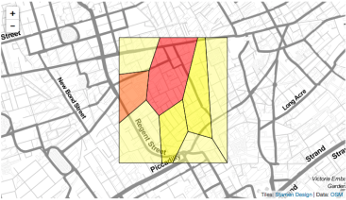

```r
pump_areas@data <- merge(
    pump_areas@data,
    data.frame(pump.id = prev$region, prev = prev$prevalence)
    )

choroMap(pump_areas, col.by="prev", directView="disabled", alpha=0.5)

# In fact, the figure below was made by running
# choroMap(pump_areas, col.by="prev", directView="browser", alpha=0.5),
# which brings up the figure in a browser window.
```

## Unusually high or low prevalence

From the map, the area surrounding the Broad Street pump seems to have a higher prevalence than areas near other pumps. But was it “unusually” high, or just the result of random local variation?

```r
    unusual_prevalence_region(cases@data, pump_areas@data[2:3], region.head="name", region.i="Broad Street")
```

```
## [1] 2.392564e-64
```

The small p-value strongly suggests something different about this area. We can do the same for every region using a single command as follows:

```r
    calculate_prevalence_unusual_pval(cases@data, pump_areas@data[2:3], region.head="name")
```

```
##                    region population cases  prevalence        lower
## 1          Briddle Street        594    46 0.077441077 5.855906e-02
## 2            Broad Street       1283   276 0.215120811 1.935045e-01
## 3         Coventry Street        525     0 0.000000000 4.305306e-19
## 4            Crown Chapel        511    71 0.138943249 1.116384e-01
## 5             Dean Street        981     0 0.000000000 0.000000e+00
## 6 Great Malborough Street        585     3 0.005128205 1.745553e-03
## 7              South Soho        935    78 0.083422460 6.735706e-02
## 8                 Warwick       1018    15 0.014734774 8.949525e-03
##         upper p.val.bonferroni sign
## 1 0.101753442     9.999999e-01    1
## 2 0.238437941     0.000000e+00    1
## 3 0.007263914     0.000000e+00   -1
## 4 0.171636079     2.190307e-05    1
## 5 0.003900586     0.000000e+00   -1
## 6 0.014967704     8.881784e-15   -1
## 7 0.102896882     9.804699e-01    1
## 8 0.024168586     0.000000e+00   -1
```

Here we see that there are only two regions which are *not* found to have unusually high or low prevalence, as judged by their large p-vales: Briddle Street and South Soho. Based on p-values, Broad Street and Crown Chapel might be classified as having high prevalence (+1 appears in the “sign” column of the output) while Coventry Street, Dean Street, Great Malborough Street and Warwick would all be classed as having unusually low prevalence compared to the area as a whole (-1 in the “sign” column).